# Data Mining - Food Environement

This notebook is part of data minig section of Integrated Project realized by food group **ResolVI** and their product **BIFIT**.

This notebook aims to bring insight on the food consumption **distribution** and **behavior** in order to optimize food environment in the United States.

[figure not shown]

# Explanitory Data Analysis

Exploratory data analysis (EDA) is used by data scientists to analyze and investigate data sets and summarize their main characteristics, often employing data visualization methods

```python
# Import useful Libraries

import pandas as pd
import numpy as np
import matplotlib.pyplot as plt
import datetime as dt
import missingno as msno
import seaborn as sns
sns.set()
from sklearn.linear_model import LinearRegression
import plotly.express as px
from sklearn.cluster import KMeans
import torch
import torch.nn as nn
from sklearn.model_selection import train_test_split
from torch.autograd import Variable
from apyori import apriori

from IPython.display import display
from sklearn.feature_selection import mutual_info_regression
from sklearn.decomposition import PCA
from sklearn import preprocessing

plt.style.use("seaborn-whitegrid")
plt.rc("figure", autolayout=True)
plt.rc(
    "axes",
    labelweight="bold",
    labelsize="large",
    titleweight="bold",
    titlesize=14,
    titlepad=10,
)

%matplotlib inline

import warnings
warnings.filterwarnings("ignore")
```

### Data Load

```python
data_excel = pd.ExcelFile("Data.xlsx")

access        = data_excel.parse("ACCESS")
assistance    = data_excel.parse("ASSISTANCE")
health        = data_excel.parse("HEALTH")
insecurity    = data_excel.parse("INSECURITY")
local         = data_excel.parse("LOCAL")
price_taxes   = data_excel.parse("PRICES_TAXES")
restaurents   = data_excel.parse("RESTAURANTS")
stores        = data_excel.parse("STORES")
socioeconomic = data_excel.parse("SOCIOECONOMIC")

datasets = [access, assistance, health, insecurity, local, price_taxes,restaurents,stores,socioeconomic]
for df in datasets[1:] :
    df.drop(columns=["FIPS","State","County"], axis='columns',inplace=True)

df = pd.concat(datasets,axis=1)
df  = df.groupby(by=["State"]).mean()
df.drop(columns=["FIPS"], inplace=True)
```

# What causes obesity & overweight?

Several factors can play a role in gaining and retaining excess weight. These include diet, lack of exercise, environmental factors, and genetics. Some of these factors are discussed briefly in the following section. The National Heart, Lung, and Blood Institute offers more information on the causes of overweight and obesity.

## Food and Activity

People gain weight when they eat more calories than they burn through activity. This imbalance is the greatest contributor to weight gain.

## Environment

The world around us influences our ability to maintain a healthy weight. For example:

- Not having area parks, sidewalks, and affordable gyms makes it hard for people to be physically active.
- Oversized food portions increase Americans’ calorie intake, making even more physical activity necessary to maintain a healthy weight.
- Some people don’t have access to supermarkets that sell affordable healthy foods, such as fresh fruits and vegetables.
- Food advertising encourages people to buy unhealthy foods, such as high-fat snacks and sugary drinks.

## Genetics

Research shows that genetics plays a role in obesity. Genes can directly cause obesity in such disorders as Prader-Willi syndrome.

Genes also may contribute to a person’s susceptibility to weight gain. Scientists believe that genes may increase a person’s likelihood of having obesity but that outside factors, such as an abundant food supply or little physical activity, also may be required for a person to have excess.

## weight

Health Conditions and Medications Some hormone problems may cause overweight and obesity, such as underactive thyroid, Cushing syndrome and polycystic ovary syndrome.

```python
target_columns = [
    'PCT_NHWHITE10','PCT_NHBLACK10','PCT_HISP10','PCT_NHASIAN10','PCT_NHNA10','PCT_NHPI10','PCT_65OLDER10','PCT_18YOUNGER10','PERPOV10','PERCHLDPOV10','METRO13',
    'PCT_DIABETES_ADULTS09','PCT_DIABETES_ADULTS10','PCT_OBESE_ADULTS09','PCT_OBESE_ADULTS10','PCT_OBESE_ADULTS13','PCT_OBESE_CHILD08','PCT_OBESE_CHILD11',
    'FMRKT09','FMRKT13','GROC07','GROC12','SUPERC07','SUPERC12','CONVS07','CONVS12','SPECS07','SPECS12','FFR07','FFR12','FSR07','FSR12',
    'PCT_LACCESS_POP10','LACCESS_LOWI10','LACCESS_CHILD10','LACCESS_SENIORS10','LACCESS_HHNV10',
    'MILK_PRICE10','SODA_PRICE10',
    'RECFACPTH07','RECFACPTH12',
]

df = df[df.columns[df.columns.isin(target_columns)]]
```

### Plot missing Data

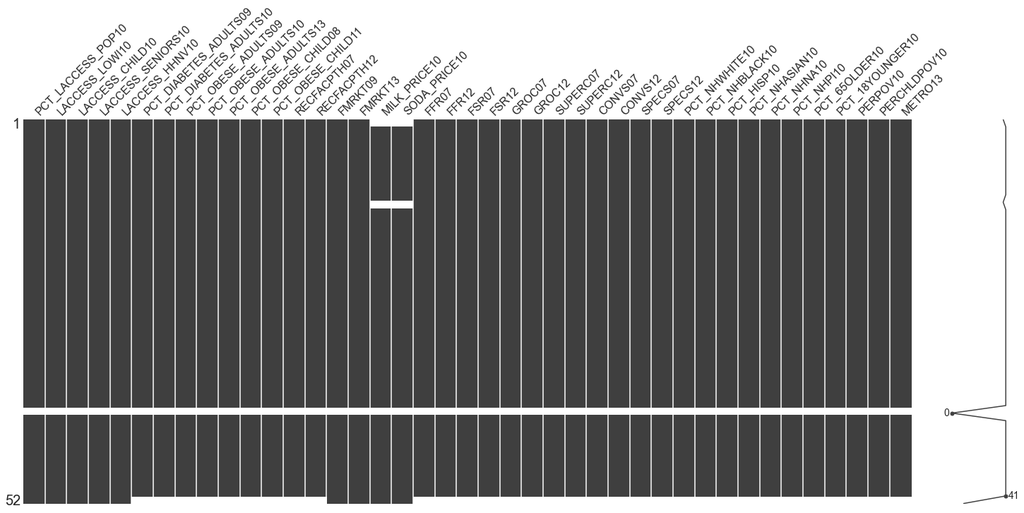

```python
msno.matrix(df)
```

### Dropping States with missing values

```python
#Create a DataFrame object
df.drop(index=['PR','WY'], inplace=True)
# delete missing values
df.replace('', np.nan, inplace=True)
df.replace('-9999', np.nan, inplace=True)
df.dropna(axis=0, how='any', inplace=True)
```

### Grouping Columns with multiple dates by computing the average value (Dimensionality reduction)

```python
diabetes = df[['PCT_DIABETES_ADULTS09', 'PCT_DIABETES_ADULTS10']]
diabetes_avg = diabetes.copy()
df['Avg_Diabetes'] = diabetes_avg.mean(axis=1)

obesity = df[['PCT_OBESE_ADULTS09','PCT_OBESE_ADULTS10','PCT_OBESE_ADULTS13']]
obesity_avg = obesity.copy()
df['Avg_Obesity_Adult'] = obesity_avg.mean(axis=1)

obesity_child = df[['PCT_OBESE_CHILD08','PCT_OBESE_CHILD11']]
obesity_avg_child = obesity_child.copy()
df['Avg_Obesity_Child'] = obesity_avg_child.mean(axis=1)

farmer_market = df[['FMRKT09', 'FMRKT13']]
farmer_market_avg = farmer_market.copy()
df['Avg_farmer_market'] = farmer_market_avg.mean(axis=1)

full_serv = df[['FSR07', 'FSR12']]
full_serv_avg = full_serv.copy()
df['Avg_full_serv'] = full_serv_avg.mean(axis=1)

fast_food = df[['FFR07', 'FFR12']]
fast_food_avg = fast_food.copy()
df['Avg_fast_food'] = fast_food_avg.mean(axis=1)

groc_stores = df[['GROC07', 'GROC12']]
groc_stores_avg = groc_stores.copy()
df['Avg_groc_store'] = groc_stores_avg.mean(axis=1)

super_stores = df[['SUPERC07', 'SUPERC12']]
super_stores_avg = super_stores.copy()
df['Avg_super_store'] = super_stores_avg.mean(axis=1)

specialized_stores = df[['SPECS07', 'SPECS12']]
specialized_stores_avg = specialized_stores.copy()
df['Avg_specialized_store'] = specialized_stores_avg.mean(axis=1)

recreation_facilities = df[['RECFACPTH07', 'RECFACPTH12']]
recreation_facilities_avg = recreation_facilities.copy()
df['Avg_recreation_facilities'] = recreation_facilities_avg.mean(axis=1)

conv_stores = df[['CONVS07', 'CONVS12']]
conv_avg = conv_stores.copy()
df['Avg_conv_store'] = conv_avg.mean(axis=1)
```

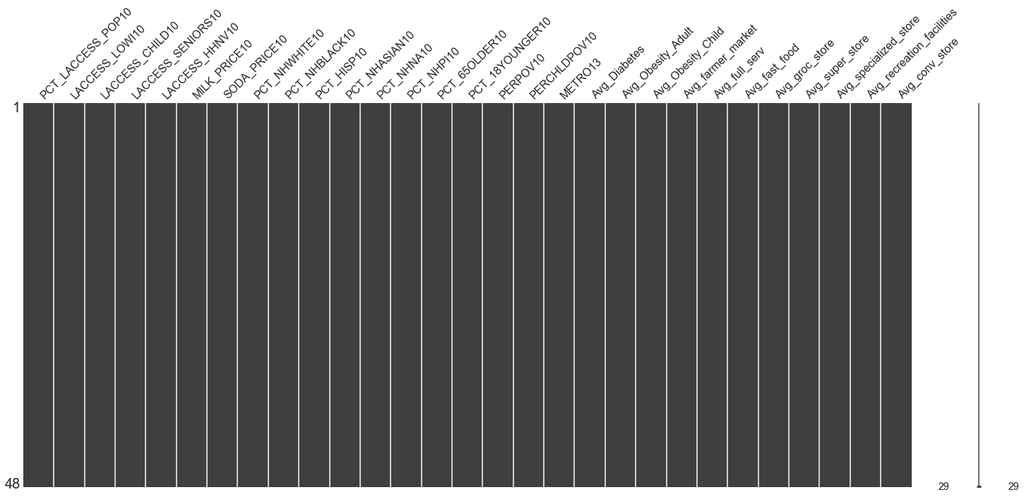

```python
avg_columns = [
    'PCT_NHWHITE10','PCT_NHBLACK10','PCT_HISP10','PCT_NHASIAN10','PCT_NHNA10','PCT_NHPI10','PCT_65OLDER10','PCT_18YOUNGER10','PERPOV10','PERCHLDPOV10','METRO13',
    'Avg_Diabetes','Avg_Obesity_Adult','Avg_Obesity_Child','Avg_farmer_market','Avg_full_serv','Avg_fast_food','Avg_groc_store',
    'Avg_super_store','Avg_specialized_store','Avg_recreation_facilities','Avg_conv_store',
    'PCT_LACCESS_POP10','LACCESS_LOWI10','LACCESS_CHILD10','LACCESS_SENIORS10','LACCESS_HHNV10',
    'MILK_PRICE10','SODA_PRICE10',
]

df = df[df.columns[df.columns.isin(avg_columns)]]
#plotting missing data
msno.matrix(df)
```

here we see that no missing data is present in the dataset, we can proceed to Data Visualization

# Data Visualization

## I - Correlation Map

Correlation is a measure of the relationship between two variables. The measure (identified by the variable r) reflects both the strength of the relation on a scale from 0 to 1 and its direction - either positive or negative. No relation is indicated when r is in the neighborhood of zero.

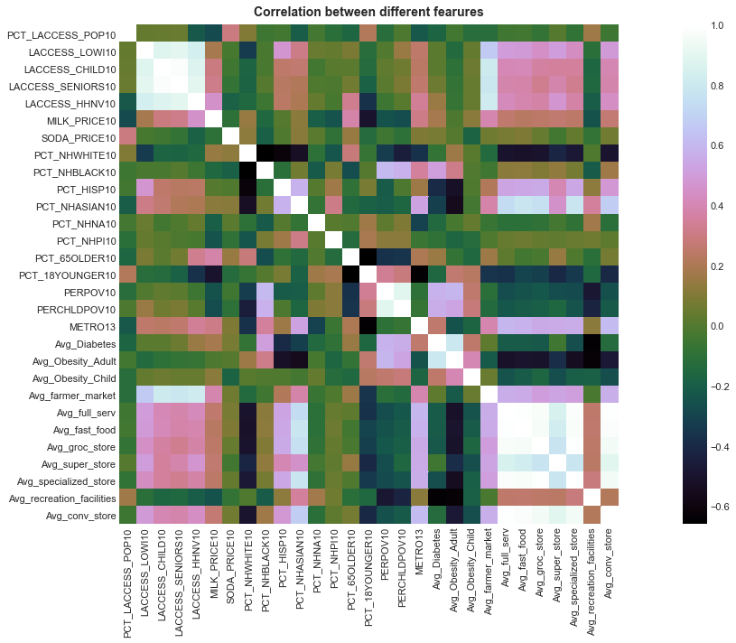

```python
correlation = df.corr()
plt.figure(figsize=(20,10))
sns.heatmap(correlation, vmax=1, square=True,annot=False,cmap='cubehelix')

plt.title('Correlation between different fearures')
```

## II - Obesity distribution by state

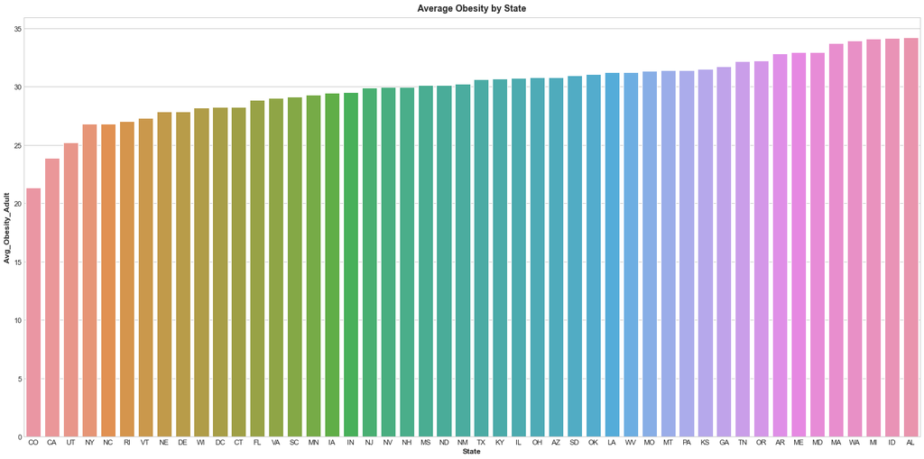

```python
df = df.sort_values(by = ['Avg_Obesity_Adult'])
plt.figure(figsize = (20, 10))
plt.title('Average Obesity by State')
sns.barplot(x = df.index, y = df['Avg_Obesity_Adult'])
```

### III - Obesity Correlation with Diabete

[figure not shown]

```
<function matplotlib.pyplot.close(fig=None)>
```

```python
# Plot obvious relationships
plt.figure(figsize=(20,10))
plt.scatter(df['Avg_Obesity_Adult'], df['Avg_Diabetes'])
plt.title("Percent Average of Diabetic vs. Percent Average of Obese")
plt.xlabel("Percent Average of Diabetic")
plt.ylabel("Percent Average of Obese")
plt.show()
plt.close
```

# Descriptive Models (Unsupervised)

Unsupervised learning is where you only have input data (X) and no corresponding output variables.

The goal for unsupervised learning is to model the **underlying structure** or **distribution** in the data in order to **learn more about the data**.

These are called unsupervised learning because unlike supervised learning above there is no correct answers and there is no teacher. Algorithms are left to their own devises to discover and present the interesting structure in the data.

Unsupervised learning problems can be further grouped into clustering and association problems.

- **Clustering** : A clustering problem is where you want to discover the inherent groupings in the data, such as grouping customers by purchasing behavior.
- **Association** : An association rule learning problem is where you want to discover rules that describe large portions of your data, such as people that buy X also tend to buy Y.

Some popular examples of unsupervised learning algorithms are:

- **k-means** for clustering problems.
- **Apriori algorithm** for association rule learning problems.

## I - K means (Clustering)

k-means clustering is a method of vector quantization, originally from signal processing, that aims to partition n observations into k clusters in which each observation belongs to the cluster with the nearest mean, serving as a prototype of the cluster.

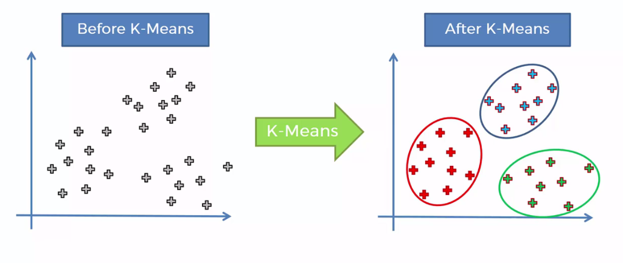

## Use elbow method to find optimal number of clusters

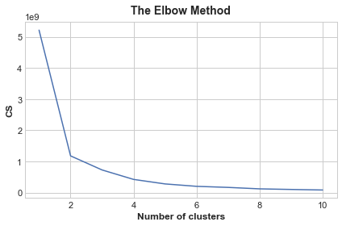

```python
cs = []
for i in range(1, 11):
    kmeans = KMeans(n_clusters = i, init = 'k-means++', max_iter = 300, n_init = 10, random_state = 0)
    kmeans.fit(df)
    cs.append(kmeans.inertia_)
plt.plot(range(1, 11), cs)
plt.title('The Elbow Method')
plt.xlabel('Number of clusters')
plt.ylabel('CS')
plt.show()
```

here we find that after 4 clusters, the model starts to fall behind, so we're using 4 as our cluster number

```python
kmeans = KMeans(n_clusters=4,random_state=0)

kmeans.fit(df)

labels = kmeans.labels_
```

```python
result = pd.DataFrame(labels , index=df.index, columns=["group"])
result["State"]  = result.index
result.reset_index(drop=True, inplace=True)
```

### Plotting the K-means result

```python
fig = px.choropleth(result,
                    locations='State',
                    locationmode="USA-states",
                    scope="usa",
                    color='group',
                    color_continuous_scale="Viridis_r"

                    )
fig.show()
```

[interactive chart not shown]

### Conclusion

```python
### kmeans_vals = result.set_index("State").squeeze().sort_index()
best_score = 0
columns = []
scores = []
for col in df.columns :
    df_sorted = df.sort_values(by = [col])
    target_col = pd.cut(df_sorted[col], bins=4, labels=False) + 1
    target_col.sort_index(inplace=True)
    score = (kmeans_vals == target_col).sum()
    columns.append(col)
    scores.append(score/df.shape[0])
    del df_sorted, target_col


# generate a dictionnary from columns and scores
score_dict = dict(zip(columns, scores))
#dict(sorted(score_dict.items(), key=lambda item: item[1],reverse=True))
pd.DataFrame.from_dict(score_dict, orient='index', columns=["Score"]).sort_values("Score",ascending=False).head(4)
```

|  | Score |
| --- | --- |
| PCT_LACCESS_POP10 | 0.2500 |
| Avg_Diabetes | 0.1875 |
| Avg_recreation_facilities | 0.1875 |
| LACCESS_LOWI10 | 0.1875 |

The most influential columns on the K-means algorithm is :

- **PCT_LACCESS_POP10** : 25%
- **LACCESS_LOWI10** : 18.75%
- **Avg_Diabetes** : 18.75%
- **Avg_recreation_facilities** : 18.75%

## II - Apriori Algorithm (Association)

The algorithm was first proposed in 1994 by **Rakesh Agrawal** and **Ramakrishnan Srikan**t. Apriori algorithm finds the most frequent itemsets or elements in a transaction database and identifies association rules between the items just like the below-mentioned example.

### 1 - Confidence

This is measured by the proportion of transactions with item I1, in which item I2 also appears. The confidence between two items I1 and I2, in a transaction is defined as the total number of transactions containing both items I1 and I2 divided by the total number of transactions containing I1.( Assume I1 as X , I2 as Y )

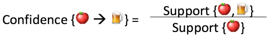

### 2 - Lift

**Lift** is the ratio between the confidence and support.

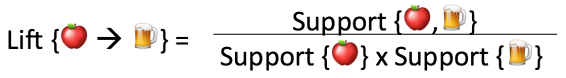

### Load the Data from Excel file

```python
# Read the external Data
food_excel = pd.ExcelFile("food_ethnicity.xlsx")
food_df = food_excel.parse("food")

# Drop missing columns
food_df.drop(columns=["Italian","State"], axis=1, inplace=True)
```

```python
top3food = []
for idx , row in food_df.iterrows():
    top3 = row.nlargest(3).index.tolist()
    if len(top3) ==3 :
        top3food.append(top3)
```

### Initialize the Apriori Model and define the parameters

```python
rules = apriori(top3food, min_support=0.003, min_confidance=0.2, min_lift=3, min_length=3)
```

```python
Results = list(rules)
# convert result in a dataframe for further operation...
df_results = pd.DataFrame(Results)
# keep support in a separate data frame so we can use later..
support = df_results.support
```

```python
#all four empty list which will contain lhs, rhs, confidance and lift respectively.
first_values = []
second_values = []
third_values = []
fourth_value = []

# loop number of rows time and append 1 by 1 value in a separate list..
# first and second element was frozenset which need to be converted in list..
for i in range(df_results.shape[0]):
    single_list = df_results['ordered_statistics'][i][0]
    first_values.append(list(single_list[0]))
    second_values.append(list(single_list[1]))
    third_values.append(single_list[2])
    fourth_value.append(single_list[3])
```

```python
# convert all four list into dataframe for further operation..
lhs = pd.DataFrame(first_values)
rhs = pd.DataFrame(second_values)

confidance=pd.DataFrame(third_values,columns=['Confidance'])

lift=pd.DataFrame(fourth_value,columns=['lift'])
```

```python
# concat all list together in a single dataframe
df_final = pd.concat([lhs,rhs,support,confidance,lift], axis=1)
df_final.fillna(value=' ', inplace=True)
#set column name
df_final.columns = ['lhs',1,'rhs','support','confidance','lift']
df_final.head()
```

|  | lhs | 1 | rhs | support | confidance | lift |
| --- | --- | --- | --- | --- | --- | --- |
| 0 | Japanese | Korean |  | 0.02 | 0.5 | 25.0 |
| 1 | Japanese | Korean | Thai | 0.02 | 0.5 | 25.0 |

As shown by the **Apriori Model**, Individuals who by **Japanses Food** have 50% chance to buy **Korean Food** and 50% chance to buy **Thai Food** .

This study aims to reduce the waste of unsold food by studying the behavior of the ethnic food consumption and always provide the right alternative for most of the cases.

# Predictive Models (Supervised)

Supervised Machine Learning The majority of practical machine learning uses supervised learning.

Supervised learning is where you have input variables (x) and an output variable (Y) and you use an algorithm to learn the mapping function from the input to the output.

Y = f(X)

The goal is to approximate the mapping function so well that when you have new input data (x) that you can predict the output variables (Y) for that data.

It is called supervised learning because the process of an algorithm learning from the training dataset can be thought of as a teacher supervising the learning process. We know the correct answers, the algorithm iteratively makes predictions on the training data and is corrected by the teacher. Learning stops when the algorithm achieves an acceptable level of performance

### I - Obesity Prediction (Linear Regression With Neural Network)

Neural networks, also known as artificial neural networks (ANNs) or simulated neural networks (SNNs), are a subset of machine learning and are at the heart of deep learning algorithms. Their name and structure are inspired by the human brain, mimicking the way that biological neurons signal to one another.

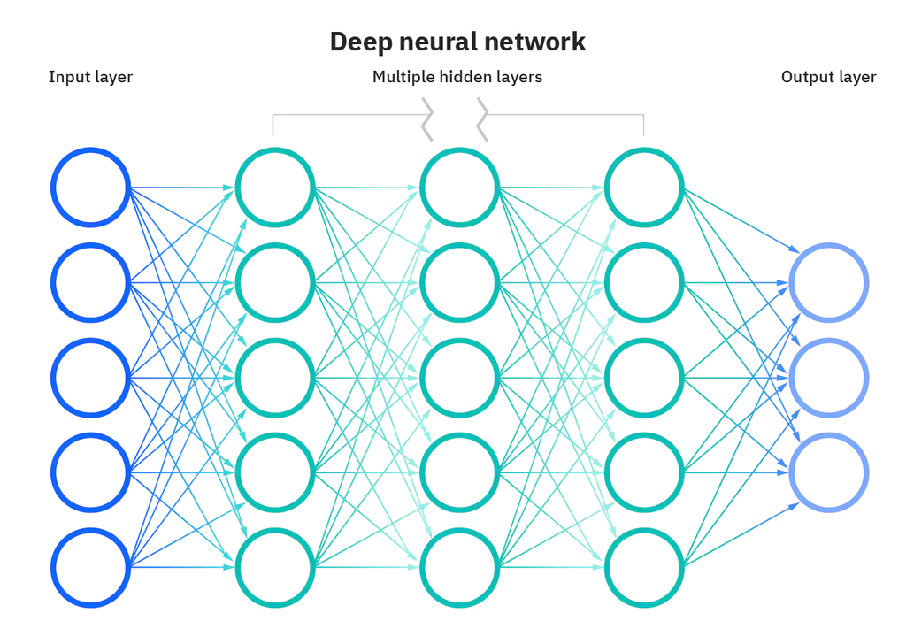

### Extract the numeric columns from data

```python
numeric_colmuns = []
numeric_colmuns.extend(list(df.dtypes[df.dtypes == np.int64].index))
numeric_colmuns.extend(list(df.dtypes[df.dtypes == np.float64].index))
numeric_data = df[df.columns[df.columns.isin(numeric_colmuns)]]

# Normalize the data
numeric_data = (numeric_data-numeric_data.mean())/numeric_data.std()
```

### define Feature column and Target column

```python
numeric_x_columns= numeric_colmuns.remove('Avg_Obesity_Adult')
numeric_y_columns = ['Avg_Obesity_Adult']
```

```python
numeric_x_df = pd.DataFrame(numeric_data, columns=numeric_x_columns)
numeric_y_df = pd.DataFrame(numeric_data, columns=numeric_y_columns)

numeric_x = torch.tensor(numeric_x_df.values, dtype=torch.float)
numeric_y = torch.tensor(numeric_y_df.values, dtype=torch.float)
```

### Split the Data into Train/Test Subsets

```python
x_train, x_test, y_train, y_test = train_test_split(numeric_x, numeric_y, test_size=0.33, random_state=42)
```

### Define the Neural Network Architecture

The Neural Network that we are using is **3-Layer Network** With **2 Hidden Layers** with Number of Neurons respectively **500** and **1000**.

#### Activation Function

Each Layer Have a module called Activation Function. It's called so because an Activation Function decides whether a neuron should be activated or not. It is a non-Linear function which is in this case ReLU (Rectified Linear Unit) that have the equation : **Y = Max(0,X)**

The equation graph corresponding to ReLU :

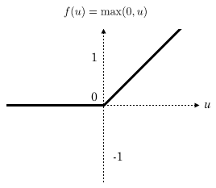

```python
class linearRegression(torch.nn.Module):
    def __init__(self, inputSize, outputSize):
        super(linearRegression, self).__init__()
        self.linear = nn.Sequential(
            nn.Linear(inputSize, 500),
            nn.ReLU(),
            nn.Linear(500, 1000),
            nn.ReLU(),
            nn.Linear(1000, outputSize)
        )
    def forward(self, x):
        out = self.linear(x)
        return out
```

### Define The model and its Hyperparameters

The learning rate is a hyperparameter that controls how much to change the model in response to the estimated error each time the model weights are updated.

```python
inputDim  = numeric_x.size()[1]       # takes variable 'x' ===> (48,28)
outputDim = numeric_y.size()[1]      # takes variable 'y' ====> (48,1)

learningRate = 0.01
epochs = 500
model = linearRegression(inputDim, outputDim)
```

### Define the loss function and Optimizer

A loss function or cost function (sometimes also called an error function) is a function that maps an event or values of one or more variables onto a real number intuitively representing some "cost" associated with the event.

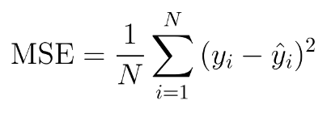

```python
criterion = torch.nn.MSELoss()
optimizer = torch.optim.SGD(model.parameters(), lr=learningRate)
```

### Initialize the Train Loop

```python
for epoch in range(epochs):
    # Converting inputs and labels to Variable

    inputs = Variable(x_train)
    labels = Variable(y_train)

    # Clear gradient buffers because we don't want any gradient from previous epoch to carry forward, dont want to cummulate gradients
    optimizer.zero_grad()

    # get output from the model, given the inputs
    outputs = model(inputs)

    # get loss for the predicted output
    loss = criterion(outputs, labels)
    #print(loss)
    # get gradients w.r.t to parameters
    loss.backward()

    # update parameters
    optimizer.step()
    if epoch%30==0 :
        print('epoch {} ;'.format(epoch))
        print('Loss : {}'.format(loss.item()))
```

```
epoch 0 ;
Loss : 1.2010318040847778
epoch 30 ;
Loss : 0.08130542188882828
epoch 60 ;
Loss : 0.021106356754899025
epoch 90 ;
Loss : 0.008996726013720036
epoch 120 ;
Loss : 0.005143385846167803
epoch 150 ;
Loss : 0.00339232268743217
epoch 180 ;
Loss : 0.0023867145646363497
epoch 210 ;
Loss : 0.0017383121885359287
epoch 240 ;
Loss : 0.0012934633996337652
epoch 270 ;
Loss : 0.0009764086571522057
epoch 300 ;
Loss : 0.0007453450234606862
epoch 330 ;
Loss : 0.0005749384872615337
epoch 360 ;
Loss : 0.00044659010018222034
epoch 390 ;
Loss : 0.0003489279479254037
epoch 420 ;
Loss : 0.0002741071511991322
epoch 450 ;
Loss : 0.00021633857977576554
epoch 480 ;
Loss : 0.0001713718957034871
```

### Model Evaluation (Inference)

```python
with torch.no_grad(): # we don't need gradients in the testing phase
    model.eval()
    predicted = model(Variable(x_test)).data.numpy()

pre_actu_array = np.concatenate((predicted,y_test.numpy()), axis=1)
accuracy_df = pd.DataFrame(pre_actu_array, columns = ['Predicted','Actual'])
```

### Visualize the model performance

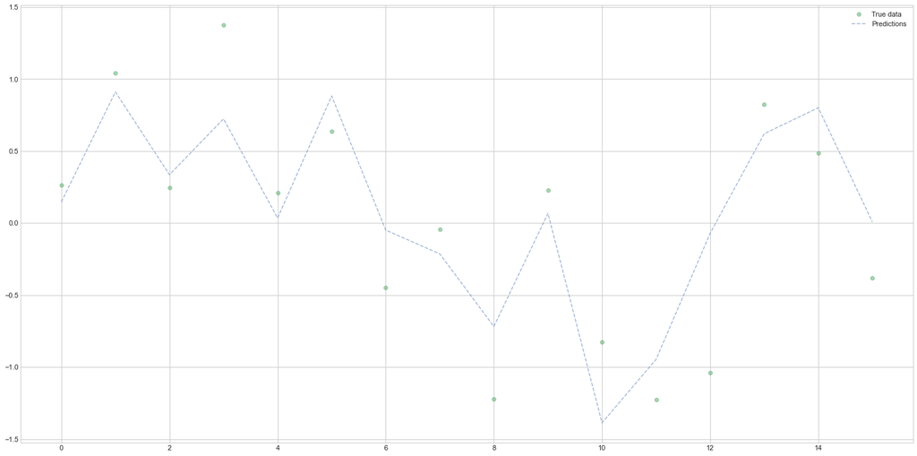

```python
plt.figure(figsize=(20,10))
plt.clf()
plt.plot(y_test, 'go', label='True data', alpha=0.5)
plt.plot(predicted, '--', label='Predictions', alpha=0.5)
plt.legend(loc='best')
plt.show()
```

## Principal Component Analysis

```python
filter_col = [col for col in df if col.startswith('Avg')]

PCA_data = df[filter_col]
filter_col.remove("Avg_Obesity_Adult")

df_PCA = PCA_data[filter_col]
y = PCA_data["Avg_Obesity_Adult"]

PCA_data = PCA_data.reset_index()
```

### Standarize the data (values between [-1,1] and mean is 0)

```python
# Standardize
df_scaled = (df_PCA - df_PCA.mean(axis=0)) / df_PCA.std(axis=0)
```

### Intitialize and fit PCA Model

```python
# Create principal components
pca = PCA(n_components=2)
X_pca = pca.fit_transform(df_scaled)
```

### Plot the PC Component of each feature

```python
# Convert to dataframe
component_names = [f"PC{i+1}" for i in range(X_pca.shape[1])]
X_pca = pd.DataFrame(X_pca, columns=component_names)

loadings = pd.DataFrame(
    pca.components_.T,  # transpose the matrix of loadings
    columns=component_names,  # so the columns are the principal components
    index=df_scaled.columns,  # and the rows are the original features
)
loadings
```

|  | PC1 | PC2 |
| --- | --- | --- |
| Avg_Diabetes | -0.102025 | -0.646397 |
| Avg_Obesity_Child | -0.106914 | -0.327271 |
| Avg_farmer_market | 0.241033 | -0.292912 |
| Avg_full_serv | 0.399680 | -0.040354 |
| Avg_fast_food | 0.396148 | -0.040448 |
| Avg_groc_store | 0.388003 | -0.035172 |
| Avg_super_store | 0.353698 | -0.090149 |
| Avg_specialized_store | 0.391912 | 0.001394 |
| Avg_recreation_facilities | 0.128518 | 0.608586 |
| Avg_conv_store | 0.397021 | -0.079121 |

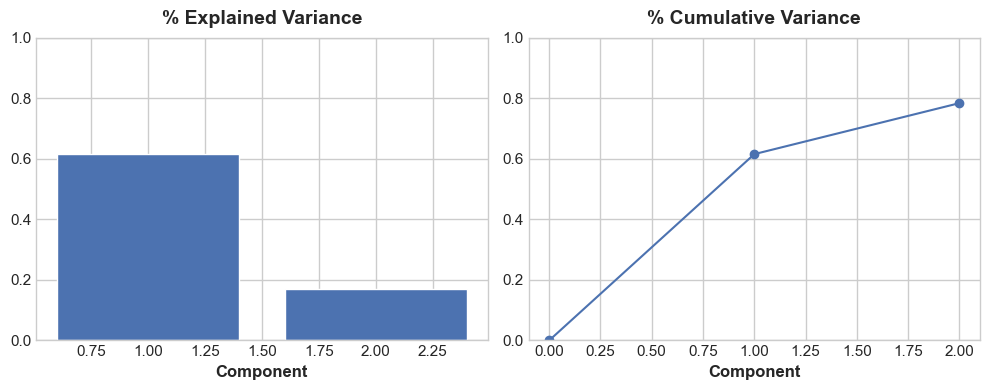

```python
def plot_variance(pca, width=8, dpi=100):
    # Create figure
    fig, axs = plt.subplots(1, 2)
    n = pca.n_components_
    grid = np.arange(1, n + 1)
    # Explained variance
    evr = pca.explained_variance_ratio_
    axs[0].bar(grid, evr)
    axs[0].set(
        xlabel="Component", title="% Explained Variance", ylim=(0.0, 1.0)
    )
    # Cumulative Variance
    cv = np.cumsum(evr)
    axs[1].plot(np.r_[0, grid], np.r_[0, cv], "o-")
    axs[1].set(
        xlabel="Component", title="% Cumulative Variance", ylim=(0.0, 1.0)
    )
    # Set up figure
    fig.set(figwidth=10, dpi=100)
    return axs


# Look at explained variance
plot_variance(pca);
```

By looking at the **% Explained Variance** , the two fist components are responsible for **78%** of the variance in the dataset, so we are keeping only **PC1** and **PC2**

Next, we measure the dependency of each component ( PC1 and PC2) with the target column **Avg_Obesity_Adult** , thus we need to compute the mi_score.

**Mutual information (MI)** between two random variables is a non-negative value, which measures the dependency between the variables. It is equal to zero if and only if two random variables are independent, and higher values mean higher dependency.

```python
def make_mi_scores(X, y, discrete_features):
    mi_scores = mutual_info_regression(X, y, discrete_features=discrete_features)
    mi_scores = pd.Series(mi_scores, name="MI Scores", index=X.columns)
    mi_scores = mi_scores.sort_values(ascending=False)
    return mi_scores


mi_scores = make_mi_scores(X_pca, y, discrete_features=False)
mi_scores
```

```
PC2    0.283973
PC1    0.170411
Name: MI Scores, dtype: float64
```

The second component have most dependency with **Avg_Obesity_Adult**. thus, we're looking for contrast between columns of PC2

The second component shows a contrast between **Avg_recreation_facilities** and **Avg_Diabetes** , the values are very diffrent. We will use them as **feature columns** in the new data

```python
# Show dataframe sorted by PC2
idx = X_pca["PC2"].sort_values(ascending=False).index
cols = ["State","Avg_recreation_facilities","Avg_Diabetes"]
PCA_data.loc[idx, cols].head(10)
```

|  | State | Avg_recreation_facilities | Avg_Diabetes |
| --- | --- | --- | --- |
| 0 | CO | 0.104325 | 6.476923 |
| 2 | UT | 0.105069 | 7.746552 |
| 9 | WI | 0.127037 | 8.528070 |
| 7 | NE | 0.090654 | 9.318817 |
| 5 | RI | 0.143211 | 9.260000 |
| 19 | NV | 0.092824 | 9.079412 |
| 16 | IA | 0.091433 | 9.334848 |
| 15 | MN | 0.118783 | 10.131034 |
| 31 | LA | 0.079952 | 10.352344 |
| 23 | NM | 0.082453 | 9.392424 |

We take the two selected feature columns from the most dependant Component and we reduce them to one column so we'll be able to plot a 2D plot with the target column

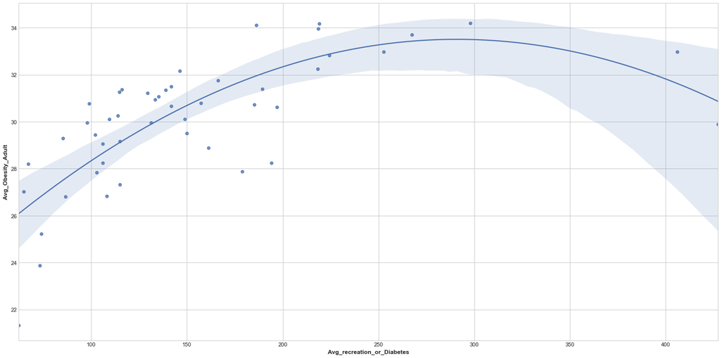

```python
plt.figure(figsize=(20,10))
df_PCA.reset_index(inplace=True)
PCA_data["Avg_recreation_or_Diabetes"] = df_PCA.Avg_Diabetes / df_PCA.Avg_recreation_facilities
sns.regplot(x="Avg_recreation_or_Diabetes", y='Avg_Obesity_Adult', data=PCA_data, order=2);
```